# Exploration

2025-10-09

## Init

```r
library(emmeans)
library(multcomp)
library(lme4)
library(lmerTest)
```

```r
library(ggplot2)
library(dplyr)
library(predictmeans)
library(lme4)
library(predictmeans)
```

# Test

```r
# setwd("C:/Users/huste/Documents/Github/businessAnalytics/Correlated Data/Assignment 1")
setwd("/home/husted42/Documents/github/businessAnalytics/Correlated Data/Assignment 1")

getwd()
```

```
## [1] "/home/husted42/Documents/github/businessAnalytics/Correlated Data/Assignment 1"
```

```r
list.files()
```

```
## [1] "AssignmentMidterm_2025 (1).pdf" "code.R"
## [3] "df_wide.csv"                    "Exploration.Rmd"
## [5] "TV2.txt"
```

```r
TV <- read.table("TV2.txt", header = 1)
TV$Assessor <- as.factor(TV$Assessor)
TV$Repeat   <- as.factor(TV$Repeat)
TV$TVset    <- as.factor(TV$TVset)
TV$Picture    <- as.factor(TV$Picture)
```

## Data

### Means

- Assessor indicates the assessor (1-8),
- TVset the television setting (TV1,TV2,TV3),
- Picture the picture (1-3),
- Repeat the replicate (0,1),
- (Target) Coloursaturation denotes the colour saturation score given by the assessor.

```r
TV
```

```
##     Assessor TVset Picture Repeat Coloursaturation
## 1          1   TV3       1      0             10.4
## 2          1   TV2       1      0              9.9
## 3          1   TV1       1      0              7.0
## 4          1   TV3       1      1              9.8
## 5          1   TV2       1      1             10.6
## 6          1   TV1       1      1              7.5
## 7          1   TV3       2      0              7.1
## 8          1   TV2       2      0              9.9
## 9          1   TV1       2      0              5.0
## 10         1   TV3       2      1             10.0
## 11         1   TV2       2      1             10.5
## 12         1   TV1       2      1              7.6
## 13         1   TV3       3      0             10.1
## 14         1   TV2       3      0             10.8
```

[output cut: 130 more lines]

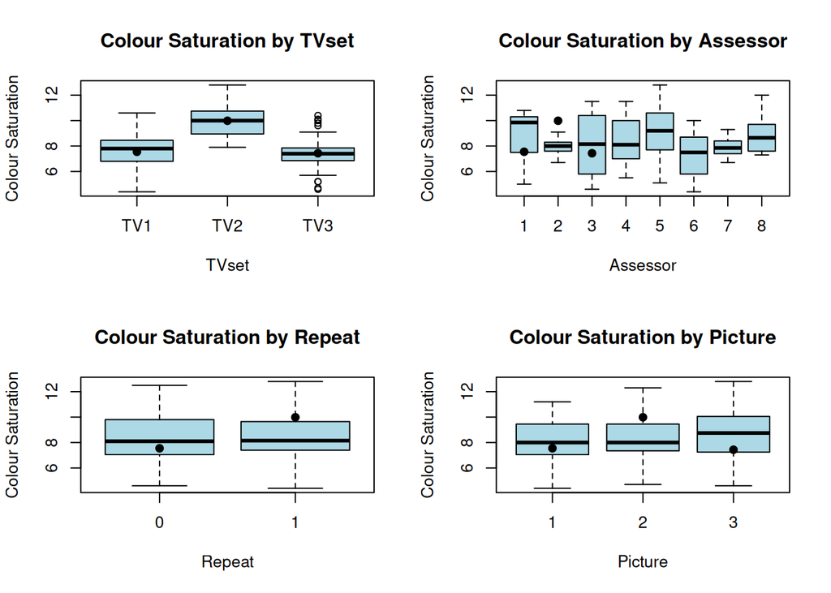

```r
vars <- c("TVset", "Assessor", "Repeat", "Picture")

par(mfrow = c(2, 2))

for (v in vars) {
  formula <- as.formula(paste("Coloursaturation ~", v))

  boxplot(formula, data = TV,
          main = paste("Colour Saturation by", v),
          xlab = v,
          ylab = "Colour Saturation",
          col = "lightblue")

          means <- tapply(TV$Coloursaturation, TV$TVset, mean)
          points(1:length(means), means, pch = 19, col = "black")

  }
```

```r
par(mfrow = c(1, 1))
```

We see a difference in mean and meadian in TVset for TV2. It’s interquartile range doesn’t overlap TV1 and TV3 Also low variance for Assessor 2 and 7

### Interactions

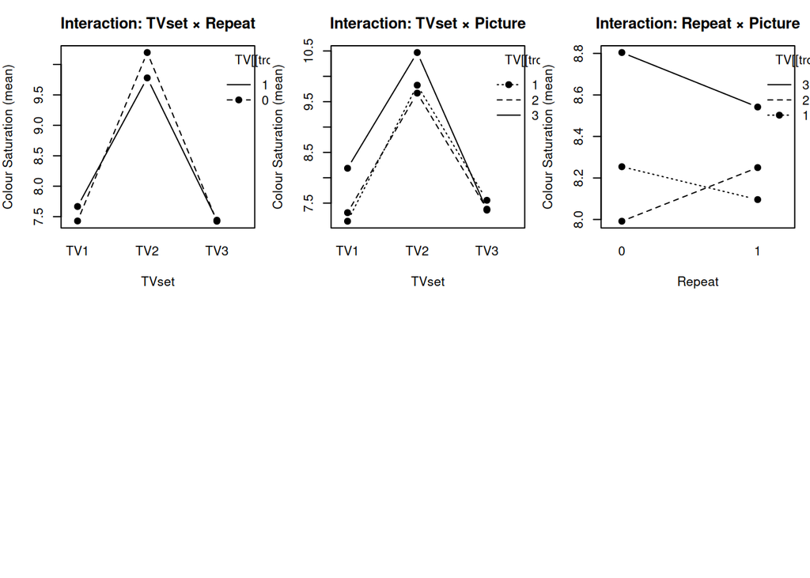

```r
# All pairwise interaction plots among these factors
vars <- c("TVset", "Repeat", "Picture")

op <- par(mfrow = c(2, 3), mar = c(4, 4, 3, 1))

pairs <- combn(vars, 2, simplify = FALSE)
for (p in pairs) {
  xfac <- p[[1]]
  trc  <- p[[2]]
  interaction.plot(
    x.factor   = TV[[xfac]],
    trace.factor = TV[[trc]],
    response   = TV$Coloursaturation,
    fun        = mean,
    type       = "b",
    pch        = 19,
    xlab       = xfac,
    ylab       = "Colour Saturation (mean)",
    legend     = TRUE,
    main       = paste("Interaction:", xfac, "×", trc)
  )
}
```

In TVset:Repeat the lines follows each other meaning that it’s unlikly there is an interaction. TVset doesn’t seem to have an impact on Repeat and vice versa. The same follows for TVset:Picture.

For repeat:picture it may look there is some interaction because the patterns doesn’t follow each other as closely, but the interval between highest and lowest value are very low, which indicate that our model won’t improve much by including it.

## Determining the model

### Interactions

```r
model_0 <- lmer(Coloursaturation ~
                TVset + Repeat + Picture +
                TVset:Repeat +
                TVset:Picture +
                Repeat:Picture +
                (1 | Assessor),

              data = TV
  )


model_1 <- lmer(Coloursaturation ~
                TVset + Repeat + Picture +
                TVset:Repeat +
                TVset:Picture +
                (1 | Assessor),
              data = TV
  )

model_2 <- lmer(Coloursaturation ~
                TVset + Repeat + Picture +
                TVset:Repeat +
                (1 | Assessor),
              data = TV
  )

model_3 <- lmer(Coloursaturation ~
                TVset + Repeat + Picture +
                (1 | Assessor),
              data = TV
  )

a1 <- anova(model_0, model_1, refit = FALSE, type = 3)
a2 <- anova(model_1, model_2, refit = FALSE, type = 3)
a3 <- anova(model_2, model_3, refit = FALSE, type = 3)

cat("#################### Anova 1 - Repeat:Pictur ####################\n")
```

```
## #################### Anova 1 - Repeat:Pictur ####################
```

```r
print(a1)
```

```
## Data: TV
## Models:
## model_1: Coloursaturation ~ TVset + Repeat + Picture + TVset:Repeat + TVset:Picture + (1 | Assessor)
## model_0: Coloursaturation ~ TVset + Repeat + Picture + TVset:Repeat + TVset:Picture + Repeat:Picture + (1 | Assessor)
##         npar    AIC    BIC  logLik -2*log(L)  Chisq Df Pr(>Chisq)
## model_1   14 489.23 530.81 -230.61    461.23
## model_0   16 491.46 538.97 -229.73    459.46 1.7723  2     0.4122
```

```r
cat("p-value =", a1$`Pr(>Chisq)`[2], "\n\n")
```

```
## p-value = 0.4122345
```

```r
cat("#################### Anova 2 - TVset:Picture ####################\n")
```

```
## #################### Anova 2 - TVset:Picture ####################
```

```r
print(a2)
```

```
## Data: TV
## Models:
## model_2: Coloursaturation ~ TVset + Repeat + Picture + TVset:Repeat + (1 | Assessor)
## model_1: Coloursaturation ~ TVset + Repeat + Picture + TVset:Repeat + TVset:Picture + (1 | Assessor)
##         npar    AIC    BIC  logLik -2*log(L)  Chisq Df Pr(>Chisq)
## model_2   10 488.44 518.13 -234.22    468.44
## model_1   14 489.23 530.81 -230.61    461.23 7.2075  4     0.1253
```

```r
cat("p-value =", a2$`Pr(>Chisq)`[2], "\n\n")
```

```
## p-value = 0.1253227
```

```r
cat("#################### Anova 3 - TVset:Repeat####################\n")
```

```
## #################### Anova 3 - TVset:Repeat####################
```

```r
print(a3)
```

```
## Data: TV
## Models:
## model_3: Coloursaturation ~ TVset + Repeat + Picture + (1 | Assessor)
## model_2: Coloursaturation ~ TVset + Repeat + Picture + TVset:Repeat + (1 | Assessor)
##         npar    AIC    BIC  logLik -2*log(L)  Chisq Df Pr(>Chisq)
## model_3    8 486.81 510.57 -235.41    470.81
## model_2   10 488.44 518.13 -234.22    468.44 2.3756  2     0.3049
```

```r
cat("p-value =", a3$`Pr(>Chisq)`[2], "\n\n")
```

```
## p-value = 0.3048863
```

```r
library(lme4)

full_formula <- Coloursaturation ~
  TVset + Repeat + Picture +
  TVset:Repeat + TVset:Picture + Repeat:Picture +
  (1 | Assessor)

terms_to_drop <- c("Repeat:Picture", "TVset:Picture", "TVset:Repeat")

models <- vector("list", length(terms_to_drop) + 1)
names(models) <- c("full", paste0("drop_", terms_to_drop))
models[[1]] <- lmer(full_formula, data = TV)

for (i in seq_along(terms_to_drop)) {
  models[[i + 1]] <- update(models[[i]], paste(". ~ . -", terms_to_drop[i]))
}

comparisons <- vector("list", length(terms_to_drop))
names(comparisons) <- paste0("Test: drop ", terms_to_drop)

for (i in seq_along(terms_to_drop)) {
  comparisons[[i]] <- anova(models[[i]], models[[i + 1]], refit = FALSE, type = 3)
}

for (i in seq_along(comparisons)) {
  term <- terms_to_drop[i]
  a <- comparisons[[i]]
  pval <- a$`Pr(>Chisq)`[nrow(a)]
  cat("\n#################### Test -", term, "####################\n")
  print(a)
  cat(sprintf("p-value = %.4g\n", pval))
}
```

```
##
## #################### Test - Repeat:Picture ####################
## Data: TV
## Models:
## models[[i + 1]]: Coloursaturation ~ TVset + Repeat + Picture + (1 | Assessor) + TVset:Repeat + TVset:Picture
## models[[i]]: full_formula
##                 npar    AIC    BIC  logLik -2*log(L)  Chisq Df Pr(>Chisq)
## models[[i + 1]]   14 489.23 530.81 -230.61    461.23
## models[[i]]       16 491.46 538.97 -229.73    459.46 1.7723  2     0.4122
## p-value = 0.4122
##
## #################### Test - TVset:Picture ####################
## Data: TV
## Models:
## models[[i + 1]]: Coloursaturation ~ TVset + Repeat + Picture + (1 | Assessor) + TVset:Repeat
## models[[i]]: Coloursaturation ~ TVset + Repeat + Picture + (1 | Assessor) + TVset:Repeat + TVset:Picture
##                 npar    AIC    BIC  logLik -2*log(L)  Chisq Df Pr(>Chisq)
## models[[i + 1]]   10 488.44 518.13 -234.22    468.44
## models[[i]]       14 489.23 530.81 -230.61    461.23 7.2075  4     0.1253
## p-value = 0.1253
##
## #################### Test - TVset:Repeat ####################
## Data: TV
## Models:
## models[[i + 1]]: Coloursaturation ~ TVset + Repeat + Picture + (1 | Assessor)
## models[[i]]: Coloursaturation ~ TVset + Repeat + Picture + (1 | Assessor) + TVset:Repeat
##                 npar    AIC    BIC  logLik -2*log(L)  Chisq Df Pr(>Chisq)
## models[[i + 1]]    8 486.81 510.57 -235.41    470.81
## models[[i]]       10 488.44 518.13 -234.22    468.44 2.3756  2     0.3049
## p-value = 0.3049
```

### Random effects

```r
model_effect <- lmer(Coloursaturation ~
                TVset + Repeat + Picture +
                (1 | Assessor),
                data = TV
  )

ranova(model_effect)
```

```
## ANOVA-like table for random-effects: Single term deletions
##
## Model:
## Coloursaturation ~ TVset + Repeat + Picture + (1 | Assessor)
##                npar  logLik    AIC    LRT Df Pr(>Chisq)
## <none>            8 -235.41 486.81
## (1 | Assessor)    7 -242.88 499.76 14.952  1  0.0001103 ***
## ---
## Signif. codes:  0 '***' 0.001 '**' 0.01 '*' 0.05 '.' 0.1 ' ' 1
```

The p-values is very small indicating systematically difference in how Assessors rate color saturation, so we keep the random effect.

### Fixed effects

```r
anova(model_effect, type = 3)
```

```
## Type III Analysis of Variance Table with Satterthwaite's method
##          Sum Sq Mean Sq NumDF DenDF F value  Pr(>F)
## TVset   199.815  99.908     2   131 71.6639 < 2e-16 ***
## Repeat    0.106   0.106     1   131  0.0758 0.78355
## Picture   8.890   4.445     2   131  3.1886 0.04445 *
## ---
## Signif. codes:  0 '***' 0.001 '**' 0.01 '*' 0.05 '.' 0.1 ' ' 1
```

We reject the null hypothesis that $ *{TVset} = 0 $ and $* {picture} = 0 $ on a significance level of 5%. We drop Repeat since it doesn’t improve the model.